# Lab 6

Author

Donya Behroozi

# Load libraries and read in data

```python
import pandas as pd
import numpy as np
from sklearn.pipeline import Pipeline
from sklearn.compose import make_column_selector, ColumnTransformer
from sklearn.preprocessing import StandardScaler, OneHotEncoder, PolynomialFeatures
from sklearn.linear_model import LinearRegression, Ridge, Lasso, ElasticNet
from sklearn.model_selection import train_test_split, cross_val_score
from sklearn.metrics import r2_score
from sklearn.model_selection import GridSearchCV
from plotnine import *

baseball = pd.read_csv("/Users/donyabehroozi/Downloads/Hitters.csv")
baseball.head()
```

|  | AtBat | Hits | HmRun | Runs | RBI | Walks | Years | CAtBat | CHits | CHmRun | CRuns | CRBI | CWalks | League | Division | PutOuts | Assists | Errors | Salary | NewLeague |
| --- | --- | --- | --- | --- | --- | --- | --- | --- | --- | --- | --- | --- | --- | --- | --- | --- | --- | --- | --- | --- |
| 0 | 293 | 66 | 1 | 30 | 29 | 14 | 1 | 293 | 66 | 1 | 30 | 29 | 14 | A | E | 446 | 33 | 20 | NaN | A |
| 1 | 315 | 81 | 7 | 24 | 38 | 39 | 14 | 3449 | 835 | 69 | 321 | 414 | 375 | N | W | 632 | 43 | 10 | 475.0 | N |
| 2 | 479 | 130 | 18 | 66 | 72 | 76 | 3 | 1624 | 457 | 63 | 224 | 266 | 263 | A | W | 880 | 82 | 14 | 480.0 | A |
| 3 | 496 | 141 | 20 | 65 | 78 | 37 | 11 | 5628 | 1575 | 225 | 828 | 838 | 354 | N | E | 200 | 11 | 3 | 500.0 | N |
| 4 | 321 | 87 | 10 | 39 | 42 | 30 | 2 | 396 | 101 | 12 | 48 | 46 | 33 | N | E | 805 | 40 | 4 | 91.5 | N |

# Clean data

First, let’s check our variable types:

```python
baseball.dtypes
```

```
AtBat          int64
Hits           int64
HmRun          int64
Runs           int64
RBI            int64
Walks          int64
Years          int64
CAtBat         int64
CHits          int64
CHmRun         int64
CRuns          int64
CRBI           int64
CWalks         int64
League        object
Division      object
PutOuts        int64
Assists        int64
Errors         int64
Salary       float64
NewLeague     object
dtype: object
```

The variable types appear to be as expected given the data description.

Now, check for missing variables:

```python
baseball.isna().sum()
```

```
AtBat         0
Hits          0
HmRun         0
Runs          0
RBI           0
Walks         0
Years         0
CAtBat        0
CHits         0
CHmRun        0
CRuns         0
CRBI          0
CWalks        0
League        0
Division      0
PutOuts       0
Assists       0
Errors        0
Salary       59
NewLeague     0
dtype: int64
```

There are 59 missing salaries. I will drop these values from the data frame. But we should not that this is a concern with this data set since our response variable contains 18% missing values.

```python
baseball = baseball.dropna()
baseball.shape[0]
```

```
263
```

Our data frame now has 322 - 59 = 263 observations.

# Part I: Different Model Specs

## A. Regression without regularization

1. Create a pipeline that includes all the columns as predictors for Salary, and performs ordinary linear regression.

First let’s define our X and y variables:

```python
X = baseball.drop(["Salary"], axis = 1)
y = baseball["Salary"]
```

```python
X.head()
```

|  | AtBat | Hits | HmRun | Runs | RBI | Walks | Years | CAtBat | CHits | CHmRun | CRuns | CRBI | CWalks | League | Division | PutOuts | Assists | Errors | NewLeague |
| --- | --- | --- | --- | --- | --- | --- | --- | --- | --- | --- | --- | --- | --- | --- | --- | --- | --- | --- | --- |
| 1 | 315 | 81 | 7 | 24 | 38 | 39 | 14 | 3449 | 835 | 69 | 321 | 414 | 375 | N | W | 632 | 43 | 10 | N |
| 2 | 479 | 130 | 18 | 66 | 72 | 76 | 3 | 1624 | 457 | 63 | 224 | 266 | 263 | A | W | 880 | 82 | 14 | A |
| 3 | 496 | 141 | 20 | 65 | 78 | 37 | 11 | 5628 | 1575 | 225 | 828 | 838 | 354 | N | E | 200 | 11 | 3 | N |
| 4 | 321 | 87 | 10 | 39 | 42 | 30 | 2 | 396 | 101 | 12 | 48 | 46 | 33 | N | E | 805 | 40 | 4 | N |
| 5 | 594 | 169 | 4 | 74 | 51 | 35 | 11 | 4408 | 1133 | 19 | 501 | 336 | 194 | A | W | 282 | 421 | 25 | A |

```python
y.head()
```

```
1    475.0
2    480.0
3    500.0
4     91.5
5    750.0
Name: Salary, dtype: float64
```

**Linear regression pipeline**

Column transformer:

```python
#column transformer that dummifies categorical variables, passes remainder through
ct_dummify_stdz = ColumnTransformer(
  [
    ("dummify",
    OneHotEncoder(sparse_output = False, handle_unknown='ignore', drop = "first"),
    make_column_selector(dtype_include=object)),
    ("standardize",
    StandardScaler(),
    make_column_selector(dtype_include=np.number))
  ],
  remainder = "passthrough"
).set_output(transform="pandas")

ct_dummify_stdz.fit_transform(X).head()
```

|  | dummify__League_N | dummify__Division_W | dummify__NewLeague_N | standardize__AtBat | standardize__Hits | standardize__HmRun | standardize__Runs | standardize__RBI | standardize__Walks | standardize__Years | standardize__CAtBat | standardize__CHits | standardize__CHmRun | standardize__CRuns | standardize__CRBI | standardize__CWalks | standardize__PutOuts | standardize__Assists | standardize__Errors |
| --- | --- | --- | --- | --- | --- | --- | --- | --- | --- | --- | --- | --- | --- | --- | --- | --- | --- | --- | --- |
| 1 | 1.0 | 1.0 | 1.0 | -0.602900 | -0.595675 | -0.528551 | -1.206112 | -0.522063 | -0.097527 | 1.397893 | 0.346791 | 0.174373 | -0.002920 | -0.121671 | 0.258966 | 0.435334 | 1.221499 | -0.523191 | 0.213352 |
| 2 | 0.0 | 1.0 | 0.0 | 0.512542 | 0.492260 | 0.729966 | 0.441515 | 0.794060 | 1.609373 | -0.901200 | -0.452865 | -0.409892 | -0.076054 | -0.415105 | -0.199590 | 0.010373 | 2.109109 | -0.253863 | 0.819964 |
| 3 | 1.0 | 0.0 | 1.0 | 0.628167 | 0.736490 | 0.958788 | 0.402286 | 1.026317 | -0.189792 | 0.770868 | 1.301558 | 1.318174 | 1.898565 | 1.412051 | 1.572666 | 0.355654 | -0.324661 | -0.744179 | -0.848219 |
| 4 | 1.0 | 0.0 | 1.0 | -0.562092 | -0.462459 | -0.185319 | -0.617673 | -0.367225 | -0.512719 | -1.110209 | -0.990935 | -0.960153 | -0.697693 | -0.947521 | -0.881228 | -0.862315 | 1.840678 | -0.543909 | -0.696566 |
| 5 | 0.0 | 1.0 | 0.0 | 1.294712 | 1.358167 | -0.871783 | 0.755349 | -0.018840 | -0.282057 | 0.770868 | 0.766993 | 0.634985 | -0.612370 | 0.422846 | 0.017294 | -0.251434 | -0.031177 | 2.087225 | 2.488147 |

Full pipeline:

```python
lr_pipeline = Pipeline(
  [("preprocessing", ct_dummify_stdz),
  ("linear_regression", LinearRegression())]
)

lr_pipeline
```

```
Pipeline(steps=[('preprocessing',
                 ColumnTransformer(remainder='passthrough',
                                   transformers=[('dummify',
                                                  OneHotEncoder(drop='first',
                                                                handle_unknown='ignore',
                                                                sparse_output=False),
                                                  <sklearn.compose._column_transformer.make_column_selector object at 0x14b1ceed0>),
                                                 ('standardize',
                                                  StandardScaler(),
                                                  <sklearn.compose._column_transformer.make_column_selector object at 0x14b1cffb0>)])),
                ('linear_regression', LinearRegression())])
```

2. Fit this pipeline to the full dataset, and interpret a few of the most important coefficients.

```python
lr_pipeline_fitted = lr_pipeline.fit(X, y)
lr_coefs = lr_pipeline_fitted.named_steps['linear_regression'].coef_
lr_abs_coefs = np.abs(lr_coefs)
lr_coef_names = lr_pipeline_fitted.named_steps["preprocessing"].get_feature_names_out()
lr_coef_df = pd.DataFrame({"Variable": lr_coef_names, "Coef": lr_coefs, "Abs Coef": lr_abs_coefs}).sort_values("Abs Coef", ascending=False)
lr_coef_df.head(5)
```

|  | Variable | Coef | Abs Coef |
| --- | --- | --- | --- |
| 13 | standardize__CRuns | 480.747135 | 480.747135 |
| 10 | standardize__CAtBat | -391.038655 | 391.038655 |
| 4 | standardize__Hits | 337.830479 | 337.830479 |
| 3 | standardize__AtBat | -291.094556 | 291.094556 |
| 14 | standardize__CRBI | 260.689886 | 260.689886 |

**Interpretations**

- CRuns: Salary is expected to increase by 480,747.1 dollars for each one standard deviation increase in number of runs during a player’s career, holding other predictors constant.
- CAtBat: Salary is expected to decrease by 391,038.7 dollars for each one standard deviation increase in number of times at bat during a player’s career, holding other predictors constant.
- Hits: Salary is expected to increase by 337,830.5 dollars for each one standard deviation increase in number of hits in 1986, holding other predictors constant.
- AtBat: Salary is expected to decrease by 291,094.6 dollars for each one standard deviation increase in number of times at bat in 1986, holding other predictors constant.
- CRBI: Salary is expected to increase by 260,689.9 dollars for each one standard deviation increase in number of runs batted in a player’s career, holding other predictors constant.
3. Use cross-validation to estimate the MSE you would expect if you used this pipeline to predict 1989 salaries.

```python
lr_scores = cross_val_score(lr_pipeline, X=X, y=y, scoring="neg_mean_squared_error", cv=5)

lr_mse = lr_scores.mean()*-1
lr_mse
```

```
np.float64(121136.31031816876)
```

The MSE we would expect if we used this pipeline to predict 1989 salaries is 121,136.31 dollars squared.

## B. Ridge regression

1. Create a pipeline that includes all the columns as predictors for Salary, and performs ordinary ridge regression.

```python
ridge_pipeline = Pipeline(
  [("preprocessing", ct_dummify_stdz),
  ("ridge_regression", Ridge())]
)

ridge_pipeline
```

```
Pipeline(steps=[('preprocessing',
                 ColumnTransformer(remainder='passthrough',
                                   transformers=[('dummify',
                                                  OneHotEncoder(drop='first',
                                                                handle_unknown='ignore',
                                                                sparse_output=False),
                                                  <sklearn.compose._column_transformer.make_column_selector object at 0x14b1ceed0>),
                                                 ('standardize',
                                                  StandardScaler(),
                                                  <sklearn.compose._column_transformer.make_column_selector object at 0x14b1cffb0>)])),
                ('ridge_regression', Ridge())])
```

2. Use cross-validation to tune the lambda hyperparameter.

```python
alphas = {'ridge_regression__alpha': np.array([100, 10, 1, 0.1, 0.01])}
gscv = GridSearchCV(ridge_pipeline, param_grid=alphas, cv = 5, scoring='r2')
gscv_fitted = gscv.fit(X, y)
df_cv_results_ = pd.DataFrame(gscv_fitted.cv_results_)
df_cv_results_[['param_ridge_regression__alpha', 'mean_test_score']]
```

|  | param_ridge_regression__alpha | mean_test_score |
| --- | --- | --- |
| 0 | 100.00 | 0.384293 |
| 1 | 10.00 | 0.370992 |
| 2 | 1.00 | 0.356488 |
| 3 | 0.10 | 0.347761 |
| 4 | 0.01 | 0.344093 |

It appears that the model that performs the best out of all the given lambda values is the model with lambda = 100.

3. Fit the pipeline with your chosen lambda to the full dataset, and interpret a few of the most important coefficients.

```python
ridge_pipeline_final = Pipeline(
  [("preprocessing", ct_dummify_stdz),
  ("ridge_regression", Ridge(alpha = 100))]
)

ridge_pipeline_fitted = ridge_pipeline_final.fit(X, y)
ridge_coefs = ridge_pipeline_fitted.named_steps['ridge_regression'].coef_
ridge_abs_coefs = np.abs(ridge_coefs)
ridge_coef_names = ridge_pipeline_fitted.named_steps["preprocessing"].get_feature_names_out()
ridge_coef_df = pd.DataFrame({"Variable": ridge_coef_names, "Coef": ridge_coefs, "Abs Coef": ridge_abs_coefs})
ridge_coef_df = ridge_coef_df.sort_values("Abs Coef", ascending=False)
ridge_coef_df.head(5)
```

|  | Variable | Coef | Abs Coef |
| --- | --- | --- | --- |
| 16 | standardize__PutOuts | 57.151970 | 57.151970 |
| 1 | dummify__Division_W | -53.025407 | 53.025407 |
| 4 | standardize__Hits | 49.783252 | 49.783252 |
| 14 | standardize__CRBI | 46.964067 | 46.964067 |
| 13 | standardize__CRuns | 45.812163 | 45.812163 |

**Interpretations**

- PutOuts: Salary is expected to increase by 57,152 dollars for each one standard deviation increase in number of put outs in 1986, holding other predictors constant.
- Division_W:

```python
baseball['Division'].value_counts()
```

```
Division
W    134
E    129
Name: count, dtype: int64
```

SD(Division_W) = sqrt((134/263)*(1-(134/263))) = 0.5

-53.025*0.5 = -26.5125

- Hits: Salary is expected to increase by 49,783.3 dollars for each one standard deviation increase in number of hits in 1986, holding other predictors constant.
- CRBI: Salary is expected to increase by 46,964.1 dollars for each one standard deviation increase in number of runs batted in during a player’s career, holding other predictors constant.
- CRuns: Salary is expected to increase by 45,812.2 dollars for each one standard deviation increase in number of runs during a player’s career, holding other predictors constant.
4. Report the MSE you would expect if you used this pipeline to predict 1989 salaries.

```python
ridge_scores = cross_val_score(ridge_pipeline_final, X=X, y=y, scoring="neg_mean_squared_error", cv=5)

ridge_mse = ridge_scores.mean()*-1
ridge_mse
```

```
np.float64(121274.42407036023)
```

The MSE we would expect if we used this pipeline to predict 1989 salaries is 121,274.424 dollars squared.

## C. Lasso Regression

1. Create a pipeline that includes all the columns as predictors for Salary, and performs ordinary lasso regression.

```python
lasso_pipeline = Pipeline(
  [("preprocessing", ct_dummify_stdz),
  ("lasso_regression", Lasso())]
)

lasso_pipeline
```

```
Pipeline(steps=[('preprocessing',
                 ColumnTransformer(remainder='passthrough',
                                   transformers=[('dummify',
                                                  OneHotEncoder(drop='first',
                                                                handle_unknown='ignore',
                                                                sparse_output=False),
                                                  <sklearn.compose._column_transformer.make_column_selector object at 0x14b1ceed0>),
                                                 ('standardize',
                                                  StandardScaler(),
                                                  <sklearn.compose._column_transformer.make_column_selector object at 0x14b1cffb0>)])),
                ('lasso_regression', Lasso())])
```

2. Use cross-validation to tune the lambda hyperparameter.

```python
alphas = {'lasso_regression__alpha': np.array([100, 10, 1, 0.1, 0.01])}
gscv = GridSearchCV(lasso_pipeline, param_grid=alphas, cv = 5, scoring='r2')
gscv_fitted = gscv.fit(X, y)
df_cv_results_ = pd.DataFrame(gscv_fitted.cv_results_)
df_cv_results_[['param_lasso_regression__alpha', 'mean_test_score']].sort_values("mean_test_score", ascending = False)
```

|  | param_lasso_regression__alpha | mean_test_score |
| --- | --- | --- |
| 1 | 10.00 | 0.369523 |
| 2 | 1.00 | 0.354238 |
| 3 | 0.10 | 0.346041 |
| 4 | 0.01 | 0.344394 |
| 0 | 100.00 | 0.298382 |

It appears that the model that performs the best out of all the given lambda values is the model with lambda = 10.

3. Fit the pipeline with your chosen lambda to the full dataset, and interpret a few of the most important coefficients.

```python
lasso_pipeline_final = Pipeline(
  [("preprocessing", ct_dummify_stdz),
  ("lasso_regression", Lasso(alpha = 10))]
)

lasso_pipeline_fitted = lasso_pipeline_final.fit(X, y)
lasso_coefs = lasso_pipeline_fitted.named_steps['lasso_regression'].coef_
lasso_abs_coefs = np.abs(lasso_coefs)
lasso_coef_names = lasso_pipeline_fitted.named_steps["preprocessing"].get_feature_names_out()
lasso_coef_df = pd.DataFrame({"Variable": lasso_coef_names, "Coef": lasso_coefs, "Abs Coef": lasso_abs_coefs})
lasso_coef_df = lasso_coef_df.sort_values("Abs Coef", ascending=False)
lasso_coef_df.head(5)
```

|  | Variable | Coef | Abs Coef |
| --- | --- | --- | --- |
| 14 | standardize__CRBI | 134.032027 | 134.032027 |
| 1 | dummify__Division_W | -95.413203 | 95.413203 |
| 4 | standardize__Hits | 88.741627 | 88.741627 |
| 13 | standardize__CRuns | 72.227529 | 72.227529 |
| 16 | standardize__PutOuts | 66.737006 | 66.737006 |

**Interpretations**

- CRBI: Salary is expected to increase by 134,032 dollars for each one standard deviation increase in number of runs batted in during a player’s career, holding other predictors constant.
- Division_W:

-95.413203*0.5 = -47.7065

- Hits: Salary is expected to increase by 88,741.6 dollars for each one standard deviation increase in number of hits in 1986, holding other predictors constant.
- CRuns: Salary is expected to increase by 72,227.5 dollars for each one standard deviation increase in number of runs during a player’s career, holding other predictors constant.
- PutOuts: Salary is expected to increase by 66,737 dollars for each one standard deviation increase in number of put outs in 1986, holding other predictors constant.
4. Report the MSE you would expect if you used this pipeline to predict 1989 salaries.

```python
lasso_scores = cross_val_score(lasso_pipeline_final, X=X, y=y, scoring="neg_mean_squared_error", cv=5)

lasso_mse = lasso_scores.mean()*-1
lasso_mse
```

```
np.float64(121828.14133338635)
```

The MSE we would expect if we used this pipeline to predict 1989 salaries is 121,828.141 dollars squared.

## D. Elastic Net

1. Create a pipeline that includes all the columns as predictors for Salary, and performs ordinary elastic net regression.

```python
elastic_net_pipeline = Pipeline(
  [("preprocessing", ct_dummify_stdz),
  ("elastic_net_regression", ElasticNet())]
)

elastic_net_pipeline
```

```
Pipeline(steps=[('preprocessing',
                 ColumnTransformer(remainder='passthrough',
                                   transformers=[('dummify',
                                                  OneHotEncoder(drop='first',
                                                                handle_unknown='ignore',
                                                                sparse_output=False),
                                                  <sklearn.compose._column_transformer.make_column_selector object at 0x14b1ceed0>),
                                                 ('standardize',
                                                  StandardScaler(),
                                                  <sklearn.compose._column_transformer.make_column_selector object at 0x14b1cffb0>)])),
                ('elastic_net_regression', ElasticNet())])
```

2. Use cross-validation to tune the lambda and alpha hyperparameters.

```python
param_grid = {
    "elastic_net_regression__alpha": np.array([100, 10, 1, 0.1, 0.01]),
    "elastic_net_regression__l1_ratio": np.array([0.0, 0.25, 0.5, 0.75, 1.0]),
}

gscv = GridSearchCV(elastic_net_pipeline, param_grid=param_grid, cv = 5, scoring='r2')
gscv_fitted = gscv.fit(X, y)
df_cv_results_ = pd.DataFrame(gscv_fitted.cv_results_)
df_cv_results_[['param_elastic_net_regression__alpha', 'param_elastic_net_regression__l1_ratio', 'mean_test_score']].sort_values("mean_test_score", ascending = False).head(5)
```

|  | param_elastic_net_regression__alpha | param_elastic_net_regression__l1_ratio | mean_test_score |
| --- | --- | --- | --- |
| 11 | 1.0 | 0.25 | 0.384872 |
| 12 | 1.0 | 0.50 | 0.384580 |
| 10 | 1.0 | 0.00 | 0.384122 |
| 13 | 1.0 | 0.75 | 0.381423 |
| 15 | 0.1 | 0.00 | 0.375991 |

It appears that the model that performs the best out of all the given lambda and alpha values is the model with lambda = 1 and alpha = 0.25

3. Fit the pipeline with your chosen hyperparameters to the full dataset, and interpret a few of the most important coefficients.

```python
elastic_net_pipeline_final = Pipeline(
  [("preprocessing", ct_dummify_stdz),
  ("elastic_net_regression", ElasticNet(alpha = 1, l1_ratio=0.25))]
)

elastic_net_pipeline_fitted = elastic_net_pipeline_final.fit(X, y)
elastic_coefs = elastic_net_pipeline_fitted.named_steps['elastic_net_regression'].coef_
elastic_abs_coefs = np.abs(elastic_coefs)
elastic_coef_names = elastic_net_pipeline_fitted.named_steps["preprocessing"].get_feature_names_out()
elastic_coef_df = pd.DataFrame({"Variable": elastic_coef_names, "Coef": elastic_coefs, "Abs Coef": elastic_abs_coefs})
elastic_coef_df = elastic_coef_df.sort_values("Abs Coef", ascending=False)
elastic_coef_df.head(5)
```

|  | Variable | Coef | Abs Coef |
| --- | --- | --- | --- |
| 16 | standardize__PutOuts | 46.140698 | 46.140698 |
| 14 | standardize__CRBI | 38.483120 | 38.483120 |
| 4 | standardize__Hits | 38.419543 | 38.419543 |
| 13 | standardize__CRuns | 37.725747 | 37.725747 |
| 11 | standardize__CHits | 36.749044 | 36.749044 |

**Interpretations**

- PutOuts: Salary is expected to increase by 46,140.7 dollars for each one standard deviation increase in number of put outs in 1986, holding other predictors constant.
- CRBI: Salary is expected to increase by 38,483.1 dollars for each one standard deviation increase in number of runs batted in during a player’s career, holding other predictors constant.
- Hits: Salary is expected to increase by 38,419.5 dollars for each one standard deviation increase in number of hits in 1986, holding other predictors constant.
- CRuns: Salary is expected to increase by 37,725.7 dollars for each one standard deviation increase in number of runs during a player’s career, holding other predictors constant.
- CHits: Salary is expected to increase by 36,749 dollars for each one standard deviation increase in number of hits during a player’s career, holding other predictors constant.
4. Report the MSE you would expect if you used this pipeline to predict 1989 salaries.

```python
elastic_scores = cross_val_score(elastic_net_pipeline_final, X=X, y=y, scoring="neg_mean_squared_error", cv=5)

elastic_mse = elastic_scores.mean()*-1
elastic_mse
```

```
np.float64(122065.01283502023)
```

The MSE we would expect if we used this pipeline to predict 1989 salaries is 122,065.013 dollars squared.

# Part II. Variable Selection

## Using only the one best numeric variable.

It appears that the most impactful/important numeric variable based on the results above is **Hits**, as this variable consistently appears as the third most impactful variable across all the models in terms of its absolute coefficient.

**Linear regression model with Hits**

```python
#column transformer that only standardizes Hits
ct_ft1 = ColumnTransformer(
  [
    ("standardize",
    StandardScaler(),
    ["Hits"])
  ],
  remainder = "drop"
).set_output(transform="pandas")

lr_ft1_pipeline = Pipeline(
  [("preprocessing", ct_ft1),
  ("linear_regression", LinearRegression())]
)

lr_ft1_scores = cross_val_score(lr_ft1_pipeline, X=X, y=y, scoring="neg_mean_squared_error", cv=5)

lr_ft1_mse = lr_ft1_scores.mean()*-1
lr_ft1_mse
```

```
np.float64(173088.97286444035)
```

The MSE of this feature set is 173,088.972 dollars squared.

**Ridge regression model with Hits**

```python
#fit pipeline
ridgeft1_pipeline = Pipeline(
  [("preprocessing", ct_ft1),
  ("ridge_regression", Ridge())]
)

#tune lambda
alphas = {'ridge_regression__alpha': np.array([100, 10, 1, 0.1, 0.01])}
gscv = GridSearchCV(ridgeft1_pipeline, param_grid=alphas, cv = 5, scoring='r2')
gscv_fitted = gscv.fit(X, y)
df_cv_results_ = pd.DataFrame(gscv_fitted.cv_results_)
df_cv_results_[['param_ridge_regression__alpha', 'mean_test_score']].sort_values('mean_test_score', ascending = False)
```

|  | param_ridge_regression__alpha | mean_test_score |
| --- | --- | --- |
| 1 | 10.00 | 0.125584 |
| 0 | 100.00 | 0.123775 |
| 2 | 1.00 | 0.122612 |
| 3 | 0.10 | 0.122253 |
| 4 | 0.01 | 0.122217 |

The model that performs the best out of the given lambdas is the model with lambda = 10.

```python
ridgeft1_pipeline_final = Pipeline(
  [("preprocessing", ct_ft1),
  ("ridge_regression", Ridge(alpha = 10))]
)

ridgeft1_scores = cross_val_score(ridgeft1_pipeline_final, X=X, y=y, scoring="neg_mean_squared_error", cv=5)

ridgeft1_mse = ridgeft1_scores.mean()*-1
ridgeft1_mse
```

```
np.float64(172755.97552343184)
```

The MSE of this feature set is 172,755.976 dollars squared.

**Lasso regression model with Hits**

```python
#fit pipeline
lassoft1_pipeline = Pipeline(
  [("preprocessing", ct_ft1),
  ("lasso_regression", Lasso())]
)

#tune lambda
alphas = {'lasso_regression__alpha': np.array([100, 10, 1, 0.1, 0.01])}
gscv = GridSearchCV(lassoft1_pipeline, param_grid=alphas, cv = 5, scoring='r2')
gscv_fitted = gscv.fit(X, y)
df_cv_results_ = pd.DataFrame(gscv_fitted.cv_results_)
df_cv_results_[['param_lasso_regression__alpha', 'mean_test_score']].sort_values("mean_test_score", ascending = False)
```

|  | param_lasso_regression__alpha | mean_test_score |
| --- | --- | --- |
| 1 | 10.00 | 0.124361 |
| 2 | 1.00 | 0.122482 |
| 3 | 0.10 | 0.122240 |
| 4 | 0.01 | 0.122216 |
| 0 | 100.00 | 0.089167 |

The model that performs the best out of the given lambdas is the model with lambda = 10.

```python
lassoft1_pipeline_final = Pipeline(
  [("preprocessing", ct_ft1),
  ("lasso_regression", Lasso(alpha = 10))]
)

lassoft1_scores = cross_val_score(lassoft1_pipeline_final, X=X, y=y, scoring="neg_mean_squared_error", cv=5)

lassoft1_mse = lassoft1_scores.mean()*-1
lassoft1_mse
```

```
np.float64(173061.63450002926)
```

The MSE of this feature set is 173,061.635 dollars squared.

**Elastic Net regression model with Hits**

```python
#fit pipeline
elasticft1_pipeline = Pipeline(
  [("preprocessing", ct_ft1),
  ("elastic_net_regression", ElasticNet())]
)

param_grid = {
    "elastic_net_regression__alpha": np.array([100, 10, 1, 0.1, 0.01]),
    "elastic_net_regression__l1_ratio": np.array([0.0, 0.25, 0.5, 0.75, 1.0]),
}

gscv = GridSearchCV(elasticft1_pipeline, param_grid=param_grid, cv = 5, scoring='r2')
gscv_fitted = gscv.fit(X, y)
df_cv_results_ = pd.DataFrame(gscv_fitted.cv_results_)
df_cv_results_[['param_elastic_net_regression__alpha', 'param_elastic_net_regression__l1_ratio', 'mean_test_score']].sort_values("mean_test_score", ascending = False).head()
```

|  | param_elastic_net_regression__alpha | param_elastic_net_regression__l1_ratio | mean_test_score |
| --- | --- | --- | --- |
| 13 | 1.0 | 0.75 | 0.129268 |
| 15 | 0.1 | 0.00 | 0.127976 |
| 16 | 0.1 | 0.25 | 0.127009 |
| 17 | 0.1 | 0.50 | 0.125758 |
| 9 | 10.0 | 1.00 | 0.124361 |

The model that performs the best out of all the given lambda and alpha values is the model with lambda = 1 and alpha = 0.75.

```python
elasticft1_pipeline_final = Pipeline(
  [("preprocessing", ct_ft1),
  ("elastic_net_regression", ElasticNet(alpha = 1, l1_ratio = 0.75))]
)

elasticft1_scores = cross_val_score(elasticft1_pipeline_final, X=X, y=y, scoring="neg_mean_squared_error", cv=5)

elasticft1_mse = elasticft1_scores.mean()*-1
elasticft1_mse
```

```
np.float64(172938.88598163932)
```

The MSE of this feature set is 172,938.886 dollars squared.

For the single best numeric variable, the ridge regression model (lambda = 10) performs the best out of all four models due to having the smallest MSE.

## Using only the five best numeric variables.

For the model with the five best numeric variables, I would start off by including Hits, CRuns, and CRBI as these variables appear to be the top five most impactful variables in terms of their absolute coefficients across all four models. In terms of the last two best numeric variables, we need to do a bit more exploration of the results from above.

**Linear regression top 10 results**

```python
lr_coef_df.head(10)
```

|  | Variable | Coef | Abs Coef |
| --- | --- | --- | --- |
| 13 | standardize__CRuns | 480.747135 | 480.747135 |
| 10 | standardize__CAtBat | -391.038655 | 391.038655 |
| 4 | standardize__Hits | 337.830479 | 337.830479 |
| 3 | standardize__AtBat | -291.094556 | 291.094556 |
| 14 | standardize__CRBI | 260.689886 | 260.689886 |
| 15 | standardize__CWalks | -213.892259 | 213.892259 |
| 8 | standardize__Walks | 135.073897 | 135.073897 |
| 1 | dummify__Division_W | -116.849246 | 116.849246 |
| 11 | standardize__CHits | 86.687617 | 86.687617 |
| 16 | standardize__PutOuts | 78.761296 | 78.761296 |

**Ridge regression top 10 results**

```python
ridge_coef_df.head(10)
```

|  | Variable | Coef | Abs Coef |
| --- | --- | --- | --- |
| 16 | standardize__PutOuts | 57.151970 | 57.151970 |
| 1 | dummify__Division_W | -53.025407 | 53.025407 |
| 4 | standardize__Hits | 49.783252 | 49.783252 |
| 14 | standardize__CRBI | 46.964067 | 46.964067 |
| 13 | standardize__CRuns | 45.812163 | 45.812163 |
| 11 | standardize__CHits | 44.468686 | 44.468686 |
| 8 | standardize__Walks | 41.647578 | 41.647578 |
| 12 | standardize__CHmRun | 38.455000 | 38.455000 |
| 6 | standardize__Runs | 29.779681 | 29.779681 |
| 10 | standardize__CAtBat | 24.510552 | 24.510552 |

**Lasso regression top 10 results**

```python
lasso_coef_df.head(10)
```

|  | Variable | Coef | Abs Coef |
| --- | --- | --- | --- |
| 14 | standardize__CRBI | 134.032027 | 134.032027 |
| 1 | dummify__Division_W | -95.413203 | 95.413203 |
| 4 | standardize__Hits | 88.741627 | 88.741627 |
| 13 | standardize__CRuns | 72.227529 | 72.227529 |
| 16 | standardize__PutOuts | 66.737006 | 66.737006 |
| 8 | standardize__Walks | 49.902813 | 49.902813 |
| 18 | standardize__Errors | -4.158281 | 4.158281 |
| 11 | standardize__CHits | 0.000000 | 0.000000 |
| 17 | standardize__Assists | 0.000000 | 0.000000 |
| 15 | standardize__CWalks | -0.000000 | 0.000000 |

**Elastic Net regression top 10 results**

```python
elastic_coef_df.head(10)
```

|  | Variable | Coef | Abs Coef |
| --- | --- | --- | --- |
| 16 | standardize__PutOuts | 46.140698 | 46.140698 |
| 14 | standardize__CRBI | 38.483120 | 38.483120 |
| 4 | standardize__Hits | 38.419543 | 38.419543 |
| 13 | standardize__CRuns | 37.725747 | 37.725747 |
| 11 | standardize__CHits | 36.749044 | 36.749044 |
| 8 | standardize__Walks | 35.353691 | 35.353691 |
| 1 | dummify__Division_W | -33.791092 | 33.791092 |
| 12 | standardize__CHmRun | 32.625791 | 32.625791 |
| 6 | standardize__Runs | 27.439170 | 27.439170 |
| 10 | standardize__CAtBat | 25.812082 | 25.812082 |

Based on the extended results from Part I, the two next best numeric variables we should include in the five best numeric variables model are CHits and Putouts, as these variables appear within the top ten largest absolute coefficients across each model. Therefore, our final five best numeric variables model will include **Hits, CRuns, CRBI, CHits, and PutOuts**

**Linear regression model with five best numeric variables**

```python
#column transformer that only standardizes Hits, CRuns, CRBI, CHits, and PutOuts
ct_ft2 = ColumnTransformer(
  [
    ("standardize",
    StandardScaler(),
    ["Hits", "CRuns", "CRBI", "CHits", "PutOuts"])
  ],
  remainder = "drop"
)

lr_ft2_pipeline = Pipeline(
  [("preprocessing", ct_ft2),
  ("linear_regression", LinearRegression())]
)

lr_ft2_scores = cross_val_score(lr_ft2_pipeline, X=X, y=y, scoring="neg_mean_squared_error", cv=5)

lr_ft2_mse = lr_ft2_scores.mean()*-1
lr_ft2_mse
```

```
np.float64(123098.16579519198)
```

The MSE of this feature set is 123,098.166 dollars squared.

**Ridge regression model with five best numeric variables**

```python
#fit pipeline
ridgeft2_pipeline = Pipeline(
  [("preprocessing", ct_ft2),
  ("ridge_regression", Ridge())]
)

#tune lambda
alphas = {'ridge_regression__alpha': np.array([100, 10, 1, 0.1, 0.01])}
gscv = GridSearchCV(ridgeft2_pipeline, param_grid=alphas, cv = 5, scoring='r2')
gscv_fitted = gscv.fit(X, y)
df_cv_results_ = pd.DataFrame(gscv_fitted.cv_results_)
df_cv_results_[['param_ridge_regression__alpha', 'mean_test_score']]
```

|  | param_ridge_regression__alpha | mean_test_score |
| --- | --- | --- |
| 0 | 100.00 | 0.381315 |
| 1 | 10.00 | 0.370263 |
| 2 | 1.00 | 0.366991 |
| 3 | 0.10 | 0.365932 |
| 4 | 0.01 | 0.365767 |

The model that performs the best out of the given lambdas is the model with lambda = 100.

```python
ridgeft2_pipeline_final = Pipeline(
  [("preprocessing", ct_ft2),
  ("ridge_regression", Ridge(alpha = 100))]
)

ridgeft2_scores = cross_val_score(ridgeft2_pipeline_final, X=X, y=y, scoring="neg_mean_squared_error", cv=5)

ridgeft2_mse = ridgeft2_scores.mean()*-1
ridgeft2_mse
```

```
np.float64(122442.74413697384)
```

The MSE of this feature set is 122,442.744 dollars squared.

**Lasso regression model with five best numeric variables**

```python
#fit pipeline
lassoft2_pipeline = Pipeline(
  [("preprocessing", ct_ft2),
  ("lasso_regression", Lasso())]
)

#tune lambda
alphas = {'lasso_regression__alpha': np.array([100, 10, 1, 0.1, 0.01])}
gscv = GridSearchCV(lassoft2_pipeline, param_grid=alphas, cv = 5, scoring='r2')
gscv_fitted = gscv.fit(X, y)
df_cv_results_ = pd.DataFrame(gscv_fitted.cv_results_)
df_cv_results_[['param_lasso_regression__alpha', 'mean_test_score']].sort_values("mean_test_score", ascending = False)
```

|  | param_lasso_regression__alpha | mean_test_score |
| --- | --- | --- |
| 1 | 10.00 | 0.368972 |
| 4 | 0.01 | 0.365733 |
| 3 | 0.10 | 0.365561 |
| 2 | 1.00 | 0.363811 |
| 0 | 100.00 | 0.294418 |

The model that performs the best out of the given lambdas is the model with lambda = 10.

```python
lassoft2_pipeline_final = Pipeline(
  [("preprocessing", ct_ft2),
  ("lasso_regression", Lasso(alpha = 10))]
)

lassoft2_scores = cross_val_score(lassoft2_pipeline_final, X=X, y=y, scoring="neg_mean_squared_error", cv=5)

lassoft2_mse = lassoft2_scores.mean()*-1
lassoft2_mse
```

```
np.float64(123165.8207689424)
```

The MSE of this feature set is 123,165.821 dollars squared.

**Elastic Net regression model with five best numeric variables**

```python
#fit pipeline
elasticft2_pipeline = Pipeline(
  [("preprocessing", ct_ft2),
  ("elastic_net_regression", ElasticNet())]
)

param_grid = {
    "elastic_net_regression__alpha": np.array([100, 10, 1, 0.1, 0.01]),
    "elastic_net_regression__l1_ratio": np.array([0.0, 0.25, 0.5, 0.75, 1.0]),
}

gscv = GridSearchCV(elasticft2_pipeline, param_grid=param_grid, cv = 5, scoring='r2')
gscv_fitted = gscv.fit(X, y)
df_cv_results_ = pd.DataFrame(gscv_fitted.cv_results_)
df_cv_results_[['param_elastic_net_regression__alpha', 'param_elastic_net_regression__l1_ratio', 'mean_test_score']].sort_values("mean_test_score", ascending = False).head()
```

|  | param_elastic_net_regression__alpha | param_elastic_net_regression__l1_ratio | mean_test_score |
| --- | --- | --- | --- |
| 12 | 1.0 | 0.50 | 0.381103 |
| 13 | 1.0 | 0.75 | 0.379351 |
| 11 | 1.0 | 0.25 | 0.377080 |
| 15 | 0.1 | 0.00 | 0.373411 |
| 16 | 0.1 | 0.25 | 0.371992 |

The model that performs the best out of all the given lambda and alpha values is the model with lambda = 1 and alpha = 0.5.

```python
elasticft2_pipeline_final = Pipeline(
  [("preprocessing", ct_ft2),
  ("elastic_net_regression", ElasticNet(alpha = 1, l1_ratio = 0.5))]
)

elasticft2_scores = cross_val_score(elasticft2_pipeline_final, X=X, y=y, scoring="neg_mean_squared_error", cv=5)

elasticft2_mse = elasticft2_scores.mean()*-1
elasticft2_mse
```

```
np.float64(122611.80994408466)
```

The MSE of this feature set is 122,611.810 dollars squared.

For the five best numeric variables, the ridge regression model (lambda = 100) performs the best out of all four models due to having the smallest MSE.

## Using the five best numeric variables and their interactions with the one best categorical variable.

We already know that Division_W is the best categorical variable for ridge and lasso regression given that this variable appears in the top five largest absolute coefficients for both models. Let’s see if this holds true for the linear and elastic net regression models.

**Linear regression best categorical variable**

```python
mask = lr_coef_df.sort_values("Abs Coef", ascending=False)["Variable"].str.contains("dummify")
lr_coef_df[mask]
```

|  | Variable | Coef | Abs Coef |
| --- | --- | --- | --- |
| 1 | dummify__Division_W | -116.849246 | 116.849246 |
| 0 | dummify__League_N | 62.599423 | 62.599423 |
| 2 | dummify__NewLeague_N | -24.762325 | 24.762325 |

**Elastic Net regression best categorical variable**

```python
mask = elastic_coef_df.sort_values("Abs Coef", ascending=False)["Variable"].str.contains("dummify")
elastic_coef_df[mask]
```

|  | Variable | Coef | Abs Coef |
| --- | --- | --- | --- |
| 1 | dummify__Division_W | -33.791092 | 33.791092 |
| 0 | dummify__League_N | 9.804670 | 9.804670 |
| 2 | dummify__NewLeague_N | 6.274399 | 6.274399 |

It does!

The five best numeric variables (as found above) are **Hits, CRuns, CRBI, CHits, and PutOuts**. The best categorical variable appears to be **Division_W**.

Let’s first define our column transformers.

Column transformer that dummifies and standardizes variables of interest:

```python
ct_ft3_dummify_stdz = ColumnTransformer(
  [
    ("dummify",
    OneHotEncoder(sparse_output = False, handle_unknown='ignore', drop = "first"),
    ["Division"]),
    ("standardize",
    StandardScaler(),
    ["Hits", "CRuns", "CRBI", "CHits", "PutOuts"])
  ],
  remainder = "drop"
).set_output(transform="pandas")

X_dummified = ct_ft3_dummify_stdz.fit_transform(X)
X_dummified.head()
```

|  | dummify__Division_W | standardize__Hits | standardize__CRuns | standardize__CRBI | standardize__CHits | standardize__PutOuts |
| --- | --- | --- | --- | --- | --- | --- |
| 1 | 1.0 | -0.595675 | -0.121671 | 0.258966 | 0.174373 | 1.221499 |
| 2 | 1.0 | 0.492260 | -0.415105 | -0.199590 | -0.409892 | 2.109109 |
| 3 | 0.0 | 0.736490 | 1.412051 | 1.572666 | 1.318174 | -0.324661 |
| 4 | 0.0 | -0.462459 | -0.947521 | -0.881228 | -0.960153 | 1.840678 |
| 5 | 1.0 | 1.358167 | 0.422846 | 0.017294 | 0.634985 | -0.031177 |

Column transformer that makes interactions between numeric and categorical variables:

```python
ct_ft3_inter = ColumnTransformer(
  [
    ("interactionHits", PolynomialFeatures(interaction_only = True, include_bias=False), ["dummify__Division_W", "standardize__Hits"]),
    ("interactionCRuns", PolynomialFeatures(interaction_only = True, include_bias=False), ["dummify__Division_W", "standardize__CRuns"]),
    ("interactionCRBI", PolynomialFeatures(interaction_only = True, include_bias=False), ["dummify__Division_W", "standardize__CRBI"]),
    ("interactionCHits", PolynomialFeatures(interaction_only = True, include_bias=False), ["dummify__Division_W", "standardize__CHits"]),
    ("interactionPutOuts", PolynomialFeatures(interaction_only = True, include_bias=False), ["dummify__Division_W", "standardize__PutOuts"])
  ],
  remainder = "drop"
).set_output(transform = "pandas")

ct_ft3_inter.fit_transform(X_dummified).head()
```

|  | interactionHits__dummify__Division_W | interactionHits__standardize__Hits | interactionHits__dummify__Division_W standardize__Hits | interactionCRuns__dummify__Division_W | interactionCRuns__standardize__CRuns | interactionCRuns__dummify__Division_W standardize__CRuns | interactionCRBI__dummify__Division_W | interactionCRBI__standardize__CRBI | interactionCRBI__dummify__Division_W standardize__CRBI | interactionCHits__dummify__Division_W | interactionCHits__standardize__CHits | interactionCHits__dummify__Division_W standardize__CHits | interactionPutOuts__dummify__Division_W | interactionPutOuts__standardize__PutOuts | interactionPutOuts__dummify__Division_W standardize__PutOuts |
| --- | --- | --- | --- | --- | --- | --- | --- | --- | --- | --- | --- | --- | --- | --- | --- |
| 1 | 1.0 | -0.595675 | -0.595675 | 1.0 | -0.121671 | -0.121671 | 1.0 | 0.258966 | 0.258966 | 1.0 | 0.174373 | 0.174373 | 1.0 | 1.221499 | 1.221499 |
| 2 | 1.0 | 0.492260 | 0.492260 | 1.0 | -0.415105 | -0.415105 | 1.0 | -0.199590 | -0.199590 | 1.0 | -0.409892 | -0.409892 | 1.0 | 2.109109 | 2.109109 |
| 3 | 0.0 | 0.736490 | 0.000000 | 0.0 | 1.412051 | 0.000000 | 0.0 | 1.572666 | 0.000000 | 0.0 | 1.318174 | 0.000000 | 0.0 | -0.324661 | -0.000000 |
| 4 | 0.0 | -0.462459 | -0.000000 | 0.0 | -0.947521 | -0.000000 | 0.0 | -0.881228 | -0.000000 | 0.0 | -0.960153 | -0.000000 | 0.0 | 1.840678 | 0.000000 |
| 5 | 1.0 | 1.358167 | 1.358167 | 1.0 | 0.422846 | 0.422846 | 1.0 | 0.017294 | 0.017294 | 1.0 | 0.634985 | 0.634985 | 1.0 | -0.031177 | -0.031177 |

**Linear regression model with five best numeric, best categorical variables, interactions**

```python
lr_ft3_pipeline = Pipeline(
  [("dummify_stdz", ct_ft3_dummify_stdz),
  ("interactions", ct_ft3_inter),
  ("linear_regression", LinearRegression())]
)

lr_ft3_scores = cross_val_score(lr_ft3_pipeline, X=X, y=y, scoring="neg_mean_squared_error", cv=5)

lr_ft3_mse = lr_ft3_scores.mean()*-1
lr_ft3_mse
```

```
np.float64(132993.94154902303)
```

The MSE of this feature set is 132,993.942 dollars squared.

**Ridge regression model with five best numeric, best categorical variables, interactions**

```python
#fit pipeline
ridgeft3_pipeline = Pipeline(
  [("dummify_stdz", ct_ft3_dummify_stdz),
  ("interactions", ct_ft3_inter),
  ("ridge_regression", Ridge())]
)

#tune lambda
alphas = {'ridge_regression__alpha': np.array([100, 10, 1, 0.1, 0.01])}
gscv = GridSearchCV(ridgeft3_pipeline, param_grid=alphas, cv = 5, scoring='r2')
gscv_fitted = gscv.fit(X, y)
df_cv_results_ = pd.DataFrame(gscv_fitted.cv_results_)
df_cv_results_[['param_ridge_regression__alpha', 'mean_test_score']]
```

|  | param_ridge_regression__alpha | mean_test_score |
| --- | --- | --- |
| 0 | 100.00 | 0.391173 |
| 1 | 10.00 | 0.368122 |
| 2 | 1.00 | 0.331874 |
| 3 | 0.10 | 0.306692 |
| 4 | 0.01 | 0.301319 |

The model that performs the best out of the given lambdas is the model with lambda = 100.

```python
ridgeft3_pipeline_final = Pipeline(
  [("dummify_stdz", ct_ft3_dummify_stdz),
  ("interactions", ct_ft3_inter),
  ("ridge_regression", Ridge(alpha = 100))]
)

ridgeft3_scores = cross_val_score(ridgeft3_pipeline_final, X=X, y=y, scoring="neg_mean_squared_error", cv=5)

ridgeft3_mse = ridgeft3_scores.mean()*-1
ridgeft3_mse
```

```
np.float64(119058.88572377394)
```

The MSE of this feature set is 119,058.886 dollars squared.

**Lasso regression model with five best numeric, best categorical variables, interactions**

```python
lassoft3_pipeline = Pipeline(
  [("dummify_stdz", ct_ft3_dummify_stdz),
  ("interactions", ct_ft3_inter),
  ("lasso_regression", Lasso())]
)

#tune lambda
alphas = {'lasso_regression__alpha': np.array([100, 10, 1, 0.1, 0.01])}
gscv = GridSearchCV(lassoft3_pipeline, param_grid=alphas, cv = 5, scoring='r2')
gscv_fitted = gscv.fit(X, y)
df_cv_results_ = pd.DataFrame(gscv_fitted.cv_results_)
df_cv_results_[['param_lasso_regression__alpha', 'mean_test_score']].sort_values('mean_test_score', ascending = False)
```

|  | param_lasso_regression__alpha | mean_test_score |
| --- | --- | --- |
| 1 | 10.00 | 0.372815 |
| 2 | 1.00 | 0.322697 |
| 3 | 0.10 | 0.300905 |
| 4 | 0.01 | 0.300666 |
| 0 | 100.00 | 0.294418 |

The model that performs the best out of the given lambdas is the model with lambda = 10.

```python
lassoft3_pipeline_final = Pipeline(
  [("dummify_stdz", ct_ft3_dummify_stdz),
  ("interactions", ct_ft3_inter),
  ("lasso_regression", Lasso(alpha = 10))]
)

lassoft3_scores = cross_val_score(lassoft3_pipeline_final, X=X, y=y, scoring="neg_mean_squared_error", cv=5)

lassoft3_mse = lassoft3_scores.mean()*-1
lassoft3_mse
```

```
np.float64(120392.80940540359)
```

The MSE of this feature set is 120,392.809 dollars squared.

**Elastic Net regression model with five best numeric, best categorical variables, interactions**

```python
elasticft3_pipeline = Pipeline(
  [("dummify_stdz", ct_ft3_dummify_stdz),
  ("interactions", ct_ft3_inter),
  ("elastic_net_regression", ElasticNet())]
)

param_grid = {
    "elastic_net_regression__alpha": np.array([100, 10, 1, 0.1, 0.01]),
    "elastic_net_regression__l1_ratio": np.array([0.0, 0.25, 0.5, 0.75, 1.0]),
}

gscv = GridSearchCV(elasticft3_pipeline, param_grid=param_grid, cv = 5, scoring='r2')
gscv_fitted = gscv.fit(X, y)
df_cv_results_ = pd.DataFrame(gscv_fitted.cv_results_)
df_cv_results_[['param_elastic_net_regression__alpha', 'param_elastic_net_regression__l1_ratio', 'mean_test_score']].sort_values("mean_test_score", ascending = False).head()
```

|  | param_elastic_net_regression__alpha | param_elastic_net_regression__l1_ratio | mean_test_score |
| --- | --- | --- | --- |
| 12 | 1.0 | 0.50 | 0.390932 |
| 13 | 1.0 | 0.75 | 0.390190 |
| 11 | 1.0 | 0.25 | 0.385267 |
| 15 | 0.1 | 0.00 | 0.378813 |
| 10 | 1.0 | 0.00 | 0.377149 |

The model that performs the best out of all the given lambda and alpha values is the model with lambda = 1 and alpha = 0.5.

```python
elasticft3_pipeline = Pipeline(
  [("dummify_stdz", ct_ft3_dummify_stdz),
  ("interactions", ct_ft3_inter),
  ("elastic_net_regression", ElasticNet(alpha = 1, l1_ratio = 0.5))]
)

elasticft3_scores = cross_val_score(elasticft3_pipeline, X=X, y=y, scoring="neg_mean_squared_error", cv=5)

elasticft3_mse = elasticft3_scores.mean()*-1
elasticft3_mse
```

```
np.float64(119301.9780582299)
```

The MSE of this feature set is 119,301.978 dollars squared.

For the five best numeric variables, best categorical variable, and their interactions, the ridge regression model (lambda = 100) performs the best out of all four models due to having the smallest MSE.

Overall, the best performing model was the ridge regression model (lambda = 100) with Hits, CRuns, CRBI, CHits, PutOuts, Division_W, and the interaction between the numeric variables and Division_W due to having the smallest MSE.

# Part III. Discussion

## A. Ridge

**Compare your Ridge models with your ordinary regression models. How did your coefficients compare? Why does this make sense?**

**Coefficient comparison: All predictors**

```python
lr_ridge_coefdf_all = lr_coef_df.merge(ridge_coef_df, on = "Variable", suffixes=("_Linear", "_Ridge"))
lr_ridge_coefdf_all[["Variable", "Coef_Linear","Coef_Ridge"]]
```

|  | Variable | Coef_Linear | Coef_Ridge |
| --- | --- | --- | --- |
| 0 | standardize__CRuns | 480.747135 | 45.812163 |
| 1 | standardize__CAtBat | -391.038655 | 24.510552 |
| 2 | standardize__Hits | 337.830479 | 49.783252 |
| 3 | standardize__AtBat | -291.094556 | -1.145684 |
| 4 | standardize__CRBI | 260.689886 | 46.964067 |
| 5 | standardize__CWalks | -213.892259 | 4.532526 |
| 6 | standardize__Walks | 135.073897 | 41.647578 |
| 7 | dummify__Division_W | -116.849246 | -53.025407 |
| 8 | standardize__CHits | 86.687617 | 44.468686 |
| 9 | standardize__PutOuts | 78.761296 | 57.151970 |
| 10 | dummify__League_N | 62.599423 | 15.495715 |
| 11 | standardize__Runs | -60.572479 | 29.779681 |
| 12 | standardize__Assists | 53.732490 | 7.582840 |
| 13 | standardize__HmRun | 37.853837 | -2.195981 |
| 14 | standardize__RBI | -26.994984 | 23.529256 |
| 15 | dummify__NewLeague_N | -24.762325 | 7.940741 |
| 16 | standardize__Errors | -22.160862 | -13.260660 |
| 17 | standardize__Years | -16.693359 | -2.694655 |
| 18 | standardize__CHmRun | -14.181723 | 38.455000 |

**Coefficient comparison: Single best numeric**

```python
lr_pipelineft1_fitted = lr_ft1_pipeline.fit(X, y)
lr_coefs = lr_pipelineft1_fitted.named_steps['linear_regression'].coef_
lr_abs_coefs = np.abs(lr_coefs)
lr_coef_names = lr_pipelineft1_fitted.named_steps["preprocessing"].get_feature_names_out()
lr_coef_df_1num = pd.DataFrame({"Variable": lr_coef_names, "Coef": lr_coefs, "Abs Coef": lr_abs_coefs}).sort_values("Abs Coef", ascending=False)

ridge_pipelineft1_fitted = ridgeft1_pipeline_final.fit(X, y)
ridge_coefs = ridge_pipelineft1_fitted.named_steps['ridge_regression'].coef_
ridge_abs_coefs = np.abs(ridge_coefs)
ridge_coef_names = ridge_pipelineft1_fitted.named_steps["preprocessing"].get_feature_names_out()
ridge_coef_df_1num = pd.DataFrame({"Variable": ridge_coef_names, "Coef": ridge_coefs, "Abs Coef": ridge_abs_coefs})
ridge_coef_df = ridge_coef_df.sort_values("Abs Coef", ascending=False)

lr_ridge_coefdf_1num = lr_coef_df_1num.merge(ridge_coef_df_1num, on = "Variable", suffixes=("_Linear", "_Ridge"))
lr_ridge_coefdf_1num[["Variable", "Coef_Linear","Coef_Ridge"]]
```

|  | Variable | Coef_Linear | Coef_Ridge |
| --- | --- | --- | --- |
| 0 | standardize__Hits | 197.517786 | 190.282702 |

**Coefficient comparison: Best five numeric**

```python
lr_pipelineft2_fitted = lr_ft2_pipeline.fit(X, y)
lr_coefs = lr_pipelineft2_fitted.named_steps['linear_regression'].coef_
lr_abs_coefs = np.abs(lr_coefs)
lr_coef_names = lr_pipelineft2_fitted.named_steps["preprocessing"].get_feature_names_out()
lr_coef_df_5num = pd.DataFrame({"Variable": lr_coef_names, "Coef": lr_coefs, "Abs Coef": lr_abs_coefs}).sort_values("Abs Coef", ascending=False)

ridge_pipelineft2_fitted = ridgeft2_pipeline_final.fit(X, y)
ridge_coefs = ridge_pipelineft2_fitted.named_steps['ridge_regression'].coef_
ridge_abs_coefs = np.abs(ridge_coefs)
ridge_coef_names = ridge_pipelineft2_fitted.named_steps["preprocessing"].get_feature_names_out()
ridge_coef_df_5num = pd.DataFrame({"Variable": ridge_coef_names, "Coef": ridge_coefs, "Abs Coef": ridge_abs_coefs})
ridge_coef_df_5num = ridge_coef_df.sort_values("Abs Coef", ascending=False)

lr_ridge_coefdf_5num = lr_coef_df_5num.merge(ridge_coef_df_5num, on = "Variable", suffixes=("_Linear", "_Ridge"))
lr_ridge_coefdf_5num[["Variable", "Coef_Linear","Coef_Ridge"]]
```

|  | Variable | Coef_Linear | Coef_Ridge |
| --- | --- | --- | --- |
| 0 | standardize__CRuns | 251.258068 | 45.812163 |
| 1 | standardize__CHits | -178.427354 | 44.468686 |
| 2 | standardize__CRBI | 152.129271 | 46.964067 |
| 3 | standardize__Hits | 121.741025 | 49.783252 |
| 4 | standardize__PutOuts | 81.471322 | 57.151970 |

**Coefficient comparison: Best five numeric, best categorical, interactions**

```python
lr_pipelineft3_fitted = lr_ft3_pipeline.fit(X, y)
lr_coefs = lr_pipelineft3_fitted.named_steps['linear_regression'].coef_
lr_abs_coefs = np.abs(lr_coefs)
lr_coef_names = lr_pipelineft3_fitted.named_steps["interactions"].get_feature_names_out()
lr_coef_df_5num1cat = pd.DataFrame({"Variable": lr_coef_names, "Coef": lr_coefs, "Abs Coef": lr_abs_coefs}).sort_values("Abs Coef", ascending=False)

ridge_pipelineft3_fitted = ridgeft3_pipeline_final.fit(X, y)
ridge_coefs = ridge_pipelineft3_fitted.named_steps['ridge_regression'].coef_
ridge_abs_coefs = np.abs(ridge_coefs)
ridge_coef_names = ridge_pipelineft3_fitted.named_steps["interactions"].get_feature_names_out()
ridge_coef_df_5num1cat = pd.DataFrame({"Variable": ridge_coef_names, "Coef": ridge_coefs, "Abs Coef": ridge_abs_coefs})
ridge_coef_df_5num1cat = ridge_coef_df_5num1cat.sort_values("Abs Coef", ascending=False)

lr_ridge_coefdf_5num1cat = lr_coef_df_5num1cat.merge(ridge_coef_df_5num1cat, on = "Variable", suffixes=("_Linear", "_Ridge"))
lr_ridge_coefdf_5num1cat[["Variable", "Coef_Linear","Coef_Ridge"]]
```

|  | Variable | Coef_Linear | Coef_Ridge |
| --- | --- | --- | --- |
| 0 | interactionCHits__dummify__Division_W standard... | 406.824397 | -9.696980 |
| 1 | interactionCHits__standardize__CHits | -284.626416 | 61.982988 |
| 2 | interactionCRBI__standardize__CRBI | 284.501480 | 85.228357 |
| 3 | interactionCRuns__dummify__Division_W standard... | -280.318489 | -10.983137 |
| 4 | interactionCRuns__standardize__CRuns | 268.519327 | 73.750563 |
| 5 | interactionCRBI__dummify__Division_W standardi... | -217.880206 | -11.732368 |
| 6 | interactionHits__standardize__Hits | 120.130927 | 87.712659 |
| 7 | interactionPutOuts__standardize__PutOuts | 89.564994 | 67.161882 |
| 8 | interactionPutOuts__dummify__Division_W standa... | -40.240490 | -7.525596 |
| 9 | interactionCRBI__dummify__Division_W | -27.053907 | -21.835344 |
| 10 | interactionCHits__dummify__Division_W | -27.053907 | -21.835344 |
| 11 | interactionPutOuts__dummify__Division_W | -27.053907 | -21.835344 |
| 12 | interactionCRuns__dummify__Division_W | -27.053907 | -21.835344 |
| 13 | interactionHits__dummify__Division_W | -27.053907 | -21.835344 |
| 14 | interactionHits__dummify__Division_W standardi... | -16.322045 | 7.730476 |

The ridge regression coefficients are generally smaller and less spread than the linear regression coefficients. This makes sense because we found our optimal lambda for the ridge regression model to be 100, which imposes quite a large penalty on our loss function. This penalty puts more emphasis on making the beta values of our ridge regression model as small as possible, instead of minimizing the sum of squared error (like in linear regression). Therefore, we would expect these coefficients to be smaller and less spread.

## B. Lasso

**Compare your LASSO model in I with your three LASSO models in II. Did you get the same lambda results? Why does this make sense? Did you get the same MSEs? Why does this make sense?**

- Lasso model I: lambda = 10, MSE = 121,828.141 dollars squared
- Lasso model II, best numeric: lambda = 10, MSE = 173,061.635 dollars squared
- Lasso model II, best 5 numeric: lambda = 10, MSE = 123,165.821 dollars squared
- Lasso model II, best 5 numeric, best categorical, interactions: lambda = 10, MSE = 120,392.809 dollars squared

## C. Elastic Net

**All predictors**

- Ridge MSE: 121,274.424 dollars squared
- Lasso MSE: 121,828.141 dollars squared
- Elastic Net MSE: 122,065.013 dollars squared

**Best numeric**

- Ridge MSE: 172,755.975 dollars squared
- Lasso MSE: 173,061.635 dollars squared
- Elastic Net MSE: 172,938.886 dollars squared

**Best 5 numeric**

- Ridge MSE: 122,442.744 dollars squared
- Lasso MSE: 123,165.821 dollars squared
- Elastic Net MSE: 122,611.810 dollars squared

**Best 5 numeric, categorical, interactions**

- Ridge MSE: 119,058.886 dollars squared
- Lasso MSE: 120,392.809 dollars squared
- Elastic Net MSE: 119,301.978 dollars squared

# Part IV. Final Model

As mentioned at the end of part II, the combination of features and models that performed best based on the validation metric of MSE is the ridge regression model (lambda = 100) with Hits, CRuns, CRBI, CHits, PutOuts, Division_W, and the interaction between the numeric variables and Division_W as predictors (smallest MSE = 119,058.886).

Let’s fit this pipeline on the full dataset:

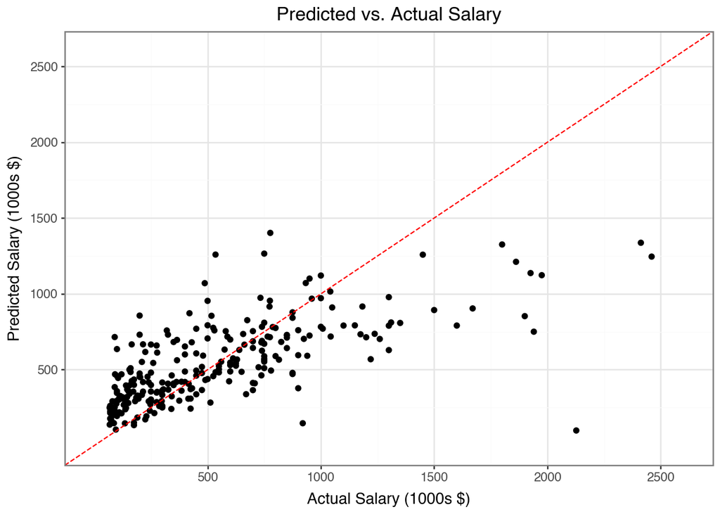

```python
ridgeft3_pipeline_final = Pipeline(
  [("dummify_stdz", ct_ft3_dummify_stdz),
  ("interactions", ct_ft3_inter),
  ("ridge_regression", Ridge(alpha = 100))]
)

ridge_pipeline_final_fitted = ridgeft3_pipeline_final.fit(X, y)
best_model_predicted_y = ridge_pipeline_final_fitted.predict(X)
actual_y = baseball["Salary"]

y_values = {"Predicted Salary": best_model_predicted_y, "Actual Salary": actual_y}
y_values = pd.DataFrame(y_values)

(ggplot(y_values,
aes(
  x = "Actual Salary",
  y = "Predicted Salary"
))
+ geom_point()
+ theme_bw()
+ labs(x = "Actual Salary (1000s $)", y = "Predicted Salary (1000s $)", title = "Predicted vs. Actual Salary")
+ geom_abline(slope=1, intercept=0, linetype="dashed", color = "red")
+ scale_y_continuous(limits = (0, 2600), breaks = [500, 1000, 1500, 2000, 2500], labels = [500, 1000, 1500, 2000, 2500])
+ scale_x_continuous(limits = (0, 2600), breaks = [500, 1000, 1500, 2000, 2500], labels = [500, 1000, 1500, 2000, 2500])
)
```

It seems that even the “best” performing model doesn’t necessarily predict our actual baseball salary values perfectly. The plot above shows instances where our model greatly underpredits actual baseball salaries and generally does not closely follow the red dashed line, representing perfect predictions. Overall, this shows me that there is really no “best” or “perfect” model that can predict baseball salary with 100% accuracy. But, this is normal with regression modeling. We explore many different models and choose the one that best predicts our response variable based on some validation metric, not the model that can perfectly predict our response variable.